# CIND 123: Data Analytics Basic Methods: Assignment-3

## Question 3 [15 Pts]

This question makes use of package “ISwR”. Please load `airquality` dataset as following:

```r
# or install.packages("ISwR")
library(ISwR)
data(airquality)
str(airquality)
```

```
## 'data.frame':    153 obs. of  6 variables:
##  $ Ozone  : int  41 36 12 18 NA 28 23 19 8 NA ...
##  $ Solar.R: int  190 118 149 313 NA NA 299 99 19 194 ...
##  $ Wind   : num  7.4 8 12.6 11.5 14.3 14.9 8.6 13.8 20.1 8.6 ...
##  $ Temp   : int  67 72 74 62 56 66 65 59 61 69 ...
##  $ Month  : int  5 5 5 5 5 5 5 5 5 5 ...
##  $ Day    : int  1 2 3 4 5 6 7 8 9 10 ...
```

## Q3a (7.5 points)

Use a histogram to assess the normality of the `Temp` variable, then explain why it appears (to some extent) normally distributed.

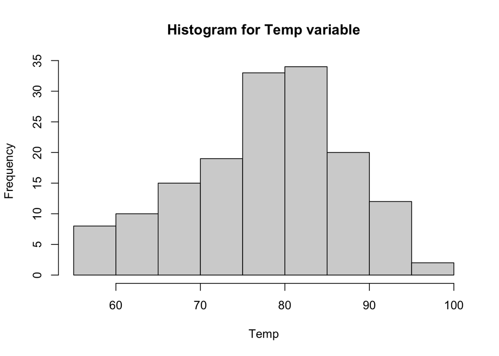

```r
#INSERT YOUR ANSWER HERE
hist(airquality$Temp, main = "Histogram for Temp variable",
      xlab = "Temp")
```

```r
mean(airquality$Temp, na.rm = T)
```

```
## [1] 77.88235
```

```r
median(airquality$Temp, na.rm = T)
```

```
## [1] 79
```

```r
sd(airquality$Temp, na.rm = T)
```

```
## [1] 9.46527
```

```r
summary(airquality$Temp, na.rm = T)
```

```
##    Min. 1st Qu.  Median    Mean 3rd Qu.    Max.
##   56.00   72.00   79.00   77.88   85.00   97.00
```

```r
# It is slightly skewed to the left. The mean and median are almost the same. The shape of the curve is also kind of symmetric. This distribution satisfies the normal distribution condition of the empirical rule which states that 99.7% of the data must be within 3 standard deviations, 95% of the data must be within 2 standard deviations, and 68% must be within 1 standard deviation from the mean.
```

## Q3b (7.5 points)

Create a comparison boxplot that shows the distribution of `Wind` in each month. Use different colours for each month.

```r
names(airquality)
```

```
## [1] "Ozone"   "Solar.R" "Wind"    "Temp"    "Month"   "Day"
```

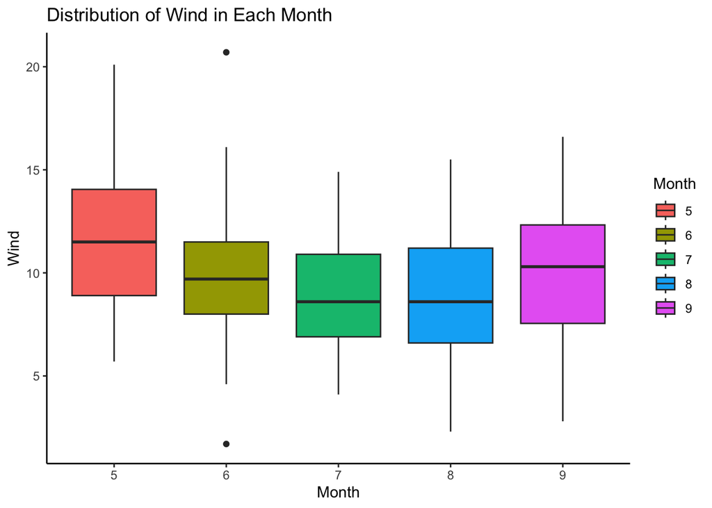

```r
#INSERT YOUR ANSWER HERE
library("ggplot2")
group_month = factor(airquality$Month)

ggplot(airquality, aes(x=group_month, y=Wind, fill = group_month)) + geom_boxplot() + theme_classic() + labs(title="Distribution of Wind in Each Month", x="Month",y="Wind") + scale_fill_discrete(name = "Month")
```

# Q4 [10 points]

Create a vector x containing 1000 random integers between 1 and 10. Write a script in `R` that uses a `for` loop to count how many of these integers are even, odd, and multiples of 4. Your script should output a message for each category, stating how many integers were found and what percentage of the total this represents. For example, your output might look something like this:

Even numbers: 488 (48.8% of total) Odd numbers: 512 (51.2% of total) Multiples of 4: 258 (25.8% of total)

You should use set.seed in the beginning with your student ID. For instance, if your student ID is 500854237, you should write down `set.seed(500854237)` in the first line, and then write the rest of the code.

- hint: Only `for` loop with `if-else` conditions are accepted.

```r
#INSERT YOUR ANSWER HERE
set.seed(501000900)

# Generate a vector of 1000 random integers between 1 and 10
random_numbers_sample <- sample(1:10, 1000, replace = TRUE)

even_count <- 0
odd_count <- 0
multiple_of_4_count <- 0

# Loop through each element and count the occurrences
for (num in random_numbers_sample) {
  # Check if the number is even
  if (num %% 2 == 0) {
    even_count <- even_count + 1
  } else {
    # Number is odd
    odd_count <- odd_count + 1
  }

  if (num %% 4 == 0) {
    # Check if the number is a multiple of 4
    multiple_of_4_count <- multiple_of_4_count + 1
  }
}

# Calculate percentages
total_integers <- length(random_numbers_sample)
even_percentage <- (even_count / total_integers) * 100
odd_percentage <- (odd_count / total_integers) * 100
multiple_of_4_percentage <- (multiple_of_4_count / total_integers) * 100

# Print output
cat("Even numbers:", even_count, "(", even_percentage, "% of total)\n")
```

```
## Even numbers: 482 ( 48.2 % of total)
```

```r
cat("Odd numbers:", odd_count, "(", odd_percentage, "% of total)\n")
```

```
## Odd numbers: 518 ( 51.8 % of total)
```

```r
cat("Multiples of 4:", multiple_of_4_count, "(", multiple_of_4_percentage, "% of total)\n")
```

```
## Multiples of 4: 206 ( 20.6 % of total)
```

** End of Assignment **